# OASIS Theory: Algebra and Implementation Details

fmrilss Development Team

2025-09-28

## Motivation

Optimized Analytic Single-pass Inverse Solution (OASIS) extends Least Squares Separate (LSS) estimation through algebraic reformulation that enables single-pass computation of all trial estimates. This document provides the mathematical foundation and implementation details.

### Computational Intuition

Standard LSS requires N separate GLM fits for N trials, each involving: 1. Matrix assembly: O(T²) operations 2. QR decomposition: O(T³) operations 3. Back-substitution: O(T²) operations

Total complexity: O(NT³) for N trials

OASIS recognizes that these N models share substantial structure. By factoring out common computations, OASIS reduces complexity to: 1. Single QR decomposition: O(T³) 2. Shared projections: O(NT²) 3. Per-trial solutions: O(N)

Total complexity: O(T³ + NT²), a significant reduction when N is large.

### Visual Comparison of Computational Scaling

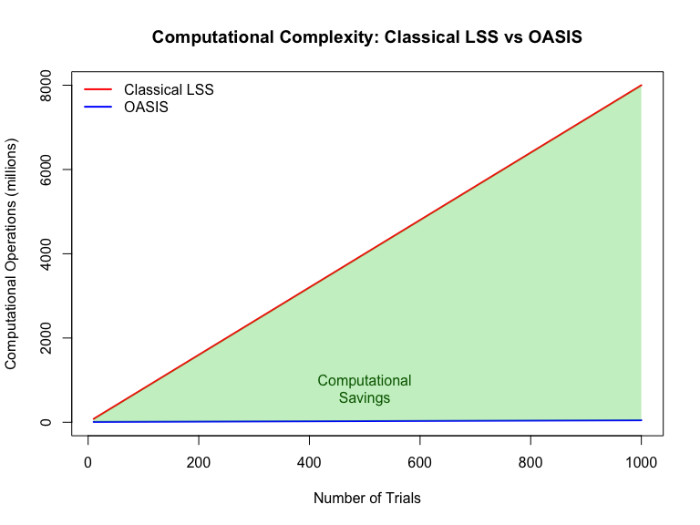

Computational complexity: Classical LSS vs OASIS

```r
# Demonstrate computational scaling
N_trials <- c(10, 50, 100, 200, 500, 1000)
T_points <- 200  # Fixed number of timepoints

# Simplified complexity models (arbitrary units)
classical_ops <- N_trials * T_points^3 / 1e6  # O(NT³)
oasis_ops <- (T_points^3 + N_trials * T_points^2) / 1e6  # O(T³ + NT²)

# Create comparison plot
plot(N_trials, classical_ops, type='l', col='red', lwd=2,
     xlab='Number of Trials', ylab='Computational Operations (millions)',
     main='Computational Complexity: Classical LSS vs OASIS',
     ylim=c(0, max(classical_ops)))
lines(N_trials, oasis_ops, col='blue', lwd=2)
legend('topleft', c('Classical LSS', 'OASIS'),
       col=c('red', 'blue'), lwd=2, bty='n')

# Add shaded region showing computational savings
polygon(c(N_trials, rev(N_trials)),
        c(classical_ops, rev(oasis_ops)),
        col=rgb(0.2, 0.8, 0.2, 0.3), border=NA)
text(500, mean(c(classical_ops[4], oasis_ops[4])),
     'Computational\nSavings', col='darkgreen')
```

### Prerequisites

This vignette assumes familiarity with: - QR decomposition and orthogonal projection matrices - Ridge regression and regularization - Matrix calculus and linear algebra - The standard LSS formulation

Code references point to `R/oasis_glue.R` and `src/oasis_core.cpp` implementations.

Notation used throughout:

- $Y \in \mathbb{R}^{T \times V}$: voxel data ($T$ time points, $V$ voxels)
- $X = [x_1, \dots, x_N] \in \mathbb{R}^{T \times N}$: trial regressors for one condition
- $Z \in \mathbb{R}^{T \times K_z}$: nuisance/experimental regressors shared across trials
- $R = I - QQ^T$: orthogonal projector removing nuisance effects ($Q$ comes from QR factorisation of $[Z,\text{others}]$)
- Inner products are denoted $\langle a, b \rangle = a^T b$

We first treat the single-basis case (one regressor per trial) before generalizing to multi-basis HRFs.

## Classical LSS Recap

Classical LSS fits, for each trial $j$, a GLM with design $[x_j, b_j, Z]$, where $b_j = \sum_{i \neq j} x_i$. Solving each model independently costs $\mathcal{O}(N)$ QR factorizations. Algebraically, the trial-specific beta can be expressed as

$$\hat{\beta}_j = \frac{\langle Rx_j, RY \rangle - \frac{\langle Rx_j,
Rb_j \rangle}{\|Rb_j\|^2} \langle Rb_j, RY \rangle}{\|Rx_j\|^2 -
\frac{\langle Rx_j, Rb_j \rangle^2}{\|Rb_j\|^2}}.$$

OASIS extracts and reuses the common computational components (projections, norms, cross-products) across all trials, computing each only once.

## Single-Basis OASIS Algebra

After residualising against nuisance regressors we define:

- $a_j = Rx_j$
- $s = \sum_{j=1}^N a_j$
- $d_j = \|a_j\|^2$
- $\alpha_j = \langle a_j, s - a_j \rangle$
- $s_j = \|s - a_j\|^2$

Let $n_{jv} = \langle a_j, RY_{\cdot v} \rangle$ and $m_v = \langle s, RY_{\cdot v} \rangle$. The pair $(\beta_j, \gamma_j)$ solving the 2×2 system for trial $j$ and voxel $v$ is obtained from

$$G_j \begin{bmatrix} \beta_{jv} \\ \gamma_{jv} \end{bmatrix} =
\begin{bmatrix} n_{jv} \\ m_v - n_{jv} \end{bmatrix},
\quad
G_j = \begin{bmatrix} d_j + \lambda_x & \alpha_j \\ \alpha_j &
s_j + \lambda_b \end{bmatrix},$$

with ridge penalties $\lambda_x, \lambda_b \ge 0$. The inverse of $G_j$ is analytic, so
$$\beta_{jv} = \frac{(s_j + \lambda_b) n_{jv} - \alpha_j (m_v -
n_{jv})}{(d_j + \lambda_x)(s_j + \lambda_b) - \alpha_j^2}.$$

This is exactly what `oasis_betas_closed_form()` implements (C++ file `src/oasis_core.cpp`). The precomputation step `oasis_precompute_design()` produces $a_j, s, d_j, \alpha_j, s_j$ once, while `oasis_AtY_SY_blocked()` streams through voxels to obtain $n_{jv}$ and $m_v$.

### Fractional Ridge

`oasis$ridge_mode = "fractional"` sets $\lambda_x = \eta_x \cdot \bar{d}$ and $\lambda_b = \eta_b \cdot \bar{s}$, where $\bar{d}$ and $\bar{s}$ are means of $d_j$ and $s_j$. The helper `.oasis_resolve_ridge()` implements this scaling. Absolute ridge uses the supplied values directly.

### Standard Errors

Given $G_j^{-1}$ and residual norm $\|RY\|^2$, the variance of $\beta_{jv}$ is

$$\operatorname{Var}(\hat{\beta}_{jv}) = \sigma_{jv}^2 \left( G_j^{-1}
\right)_{11}, \quad \sigma_{jv}^2 = \frac{\text{SSE}_{jv}}{\text{dof}},$$

with

$$\text{SSE}_{jv} = \|RY_{\cdot v}\|^2 - 2 (\beta_{jv} n_{jv} +
\gamma_{jv} (m_v - n_{jv})) + d_j \beta_{jv}^2 + s_j \gamma_{jv}^2 + 2
\alpha_j \beta_{jv} \gamma_{jv}.$$

`.oasis_se_from_norms()` realises this computation, reusing $n_{jv}$, $m_v$ and the cached design scalars.

## Multi-Basis Extension

When the HRF contributes $K > 1$ basis functions, each trial has columns $A_j \in \mathbb{R}^{T \times K}$. Define

- $S = \sum_j A_j$
- $D_j = A_j^T A_j$
- $C_j = A_j^T (S - A_j)$
- $E_j = (S - A_j)^T (S - A_j)$

Per voxel we need $N1 = A^T RY$ (stacked $N$ blocks of size $K$) and $SY = S^T RY$. The block system is

$$\begin{bmatrix}
D_j + \lambda_x I & C_j \\
C_j^T & E_j + \lambda_b I
\end{bmatrix}
\begin{bmatrix}
B_{jv} \\
\Gamma_{jv}
\end{bmatrix}
=
\begin{bmatrix}
N1_{jv} \\
SY_v - N1_{jv}
\end{bmatrix},$$

where $B_{jv} \in \mathbb{R}^K$. `oasisk_betas()` solves this 2K×2K system via Cholesky factorisation. Ridge again adds $\lambda_x I$ and $\lambda_b I$ to the block diagonals. Compared to the single-basis path, only the shapes of the cached matrices differ; the solve is still analytic per trial/voxel block.

The companion `oasisk_betas_se()` extends the SSE/variance calculation to the multi-basis case, using the same building blocks.

## HRF-Aware Design Construction

OASIS can construct $X$ on the fly from event specifications. `.oasis_build_X_from_events()` uses `fmrihrf::regressor_set()` to generate trial-wise columns (and optional other-condition aggregates) given:

- `cond$onsets`: per-trial onset times
- `cond$hrf`: HRF object (canonical, FIR, multi-basis, user-defined)
- `cond$span`, `precision`, `method`: convolution controls

This design is then residualised against nuisance regressors and fed into the algebra above. Because the HRF definition enters directly, switching HRFs or running grid searches automatically regenerates a matching design. When you provide an explicit `X`, OASIS skips this step and assumes you have already encoded the HRF in the matrix.

## AR(1) Whitening

`oasis$whiten = "ar1"` estimates a common AR(1) coefficient from residualised data. `.oasis_ar1_whitener()` computes $\rho$ and applies Toeplitz-safe differencing:

$$\tilde{y}_t = \begin{cases}
\sqrt{1 - \rho^2} y_1 & t = 1, \\
y_t - \rho y_{t-1} & t > 1.
\end{cases}$$

The same transformation is applied to $X$ and nuisance regressors before the standard OASIS algebra runs. Whitening preserves the single-pass benefits because the transformed data are treated exactly like the original inputs.

## Diagnostics Output

When `oasis$return_diag = TRUE`, OASIS returns the precomputed design scalars:

- Single-basis: $d_j, \alpha_j, s_j$ (from `oasis_precompute_design()`)
- Multi-basis: $D_j, C_j, E_j$ (from `oasisk_precompute_design()`)

These matrices are useful for checking trial collinearity, energy, and the effect of ridge scaling.

## Algorithm Summary

Putting everything together, the single-basis solver proceeds as follows:

1. Residualise $Y$ and $X$ against nuisance regressors, optionally with whitening.
2. Compute $a_j, s, d_j, \alpha_j, s_j$ (`oasis_precompute_design`).
3. Stream through voxels in blocks, forming $N_Y = A^T RY$ and $S_Y = s^T RY$ (`oasis_AtY_SY_blocked`).
4. Apply ridge scaling (absolute or fractional) to obtain $\lambda_x, \lambda_b$.
5. For each trial, evaluate the closed-form $\beta_{jv}$ (and $\gamma_{jv}$ if SEs requested).
6. Optionally compute SEs and diagnostics.

The multi-basis path swaps steps 2–5 for their block equivalents. In both cases, the cost is dominated by the single projection of $Y$ and the matrix–vector multiplies in step 3, giving $\mathcal{O}(T V)$ complexity with a small trial-dependent overhead.

## Complexity and Memory

- Projection / whitening: $\mathcal{O}(T V K_z)$ arithmetic, $\mathcal{O}(T K_z)$ memory for confounds
- Precomputation: $\mathcal{O}(T N)$
- Products (blocked): $\mathcal{O}(T V)$ with block size tuning
- Closed-form solves: $\mathcal{O}(N V)$ with negligible constants (2×2 or 2K×2K systems)

Compared to classical LSS ($N$ separate regressions), OASIS shaves off repeated projections and linear solves, yielding substantial speedups when $N$ or $V$ is large.

## References

- Mumford, J. A., Turner, B. O., Ashby, F. G., & Poldrack, R. A. (2012). Deconvolving BOLD activation in event-related designs for multivoxel pattern classification analyses. *NeuroImage*, 59(3), 2636–2643.
- fmrilss source files `R/oasis_glue.R` and `src/oasis_core.cpp` (for implementation alignment).